# Permutation-based multiple testing with R - lab 1/2

## Linear Trend, the least squares method

\(Reaction.Time \approx \beta_0 + \beta_1 Temperature\)  
\(Y=\beta_0 + \beta_1X\)

Let's draw a line 'in the middle' of the data.

The **least-squares estimator**

We look for the one that passes more 'in the middle', the one that minimizes the sum of the squares of the residues:

\(\hat{\beta}_0\) and \(\hat{\beta}_1\) such that  
\(\sum_{i=1} ^ n (y_i - (\hat{\beta}_0 + \hat{\beta}_1x_i )) ^ 2\) is minimum.

Estimates:

- Angular coefficient: \(\hat{\beta}_1=\frac{\sigma_{xy}}{\sigma_{xx}}=\rho_{xy}\frac{\sigma_{y}}{\sigma_{x}}=\frac{\sum_{i=1}^n(x_i- \bar{x})(y_i-\bar{y})}{\sum_{i=1}^n (x_i-\bar{x})^2}=\) 0.2064719
- Intercept: \(\hat{\beta}_0=\bar{y}-\hat{\beta}_1\bar{x}=\) 10.3013483
- Response (estimated \(y\)): \(\hat{y}_i=\hat{\beta}_0 + \hat{\beta}_1x_i\)
- Residuals (from the estimated response): \(y_i - (\hat{\beta}_0 + \hat{\beta}_1 x_i)=y_i- \hat{y}_i\)

and therefore the least squares are the sum of the squared residuals: \(\sum_{i=1} ^ n (y_i- \hat{\beta}_0 + \hat{\beta}_1x_i) ^ 2=\sum_{i=1} ^ n (y_i- \hat{y}_i ) ^ 2\)

A graphical representation:

```r
model=lm(Reaction.Time~Age,data=reaction)
coefficients(model)
```

```
## (Intercept)         Age
##  10.3013483   0.2064719
```

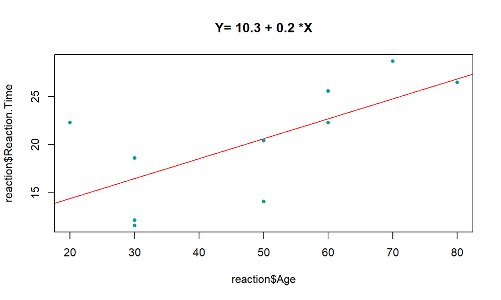

```r
plot(reaction$Age,reaction$Reaction.Time,pch=20,col=2,cex=1)
coeff=round(coefficients(model),1)
title(paste("Y=",coeff[1],"+",coeff[2],"*X"))
abline(model,col=1)
```

## Permutation approach to Hypothesis Testing

## Some remarks

Let's note that all the measures above does not make any assumptions on the random process that generate them.

Let now assume that \(Y\) - and possibly \(X\) - is generated by a random variable.

Further minimal assumptions will be specified later.

The question: **Is there a relationship between \(Y\) and \(X\)**?

We estimated \(\hat{\beta}_1=\) 0.2064719

but the **true value** \(\beta_1\) is really different from 0 (i.e. no relationship)?  
Otherwise, is the distance to 0 is due to the random sampling?

- **Null Hypothesis** \(H_0: \ \beta_1=0\) (the **true** \(\beta_1\), not its estimate \(\hat{\beta}_1\)!). There is no relationship between \(X\) and \(Y\).
- **Alternative Hypothesis** \(H_1: \ \beta_1 >0\) The relationship is positive.

Other possible specifications of \(H_1: \ \beta_1< 0\) and, more commonly, \(H_1: \ \beta_1 \neq 0\).

## Permutation tests - in a nutshell

As a toy example, let use a sub-set of the data:

```
##   Age Gender Reaction.Time
## 3  30      M         11.62
## 8  30      M         18.59
## 4  60      F         22.27
```

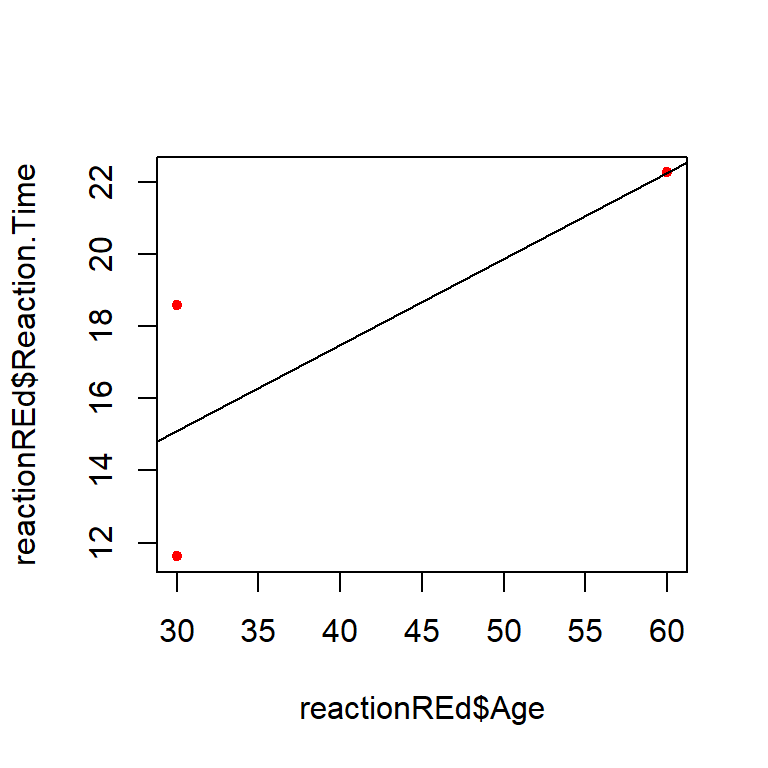

- *If \(H_0\)* is true: there is no linear relationship between \(X\) and \(Y\)
- Therefore, the trend observed on the data is due to chance.
- Any other match of \(x_i\) and \(y_i\) was equally likely to occur
- I can generate the datasets of other hypothetical experiments by exchanging the order of the observations in \(Y\).
- How many equally likely datasets could I get with\(X\) and \(Y\)observed? \(3 * 2 * 1=3!=6\) possible datasets.

Remark: Here we only assume that \(y\) is a random variable. The only assumption here is the exchangeability of the observations: the joint density \(f(y_1,\ldots,y_n)\) does not change when the ordering of \(y_1,\ldots,y_n\) is changed.

## All potential datasets

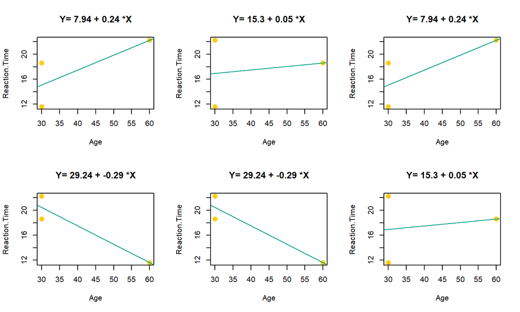

### In our data set

We apply the same principle to the complete dataset…

How many permutations of the vector \(y_1,\ldots,y_n\) are possible? \(n!=\) 3.628810^{6}.

big, perhaps not too big … but what happen with, for example, \(n=20\)? We got \(20!=\) 2.43290210^{18}. This is too big, definitely!

We calculate a smaller (but sufficiently large) \(B\) of random permutations.

here some example

[figure not shown]

We repeat 10^{4} times and we look at the histogram of the \(\hat{\beta}_1\)

```r
# beta_1 estimated on the observed data:
beta1=coefficients(lm(Reaction.Time~Age,data=reaction))[2]

# function that permutes the y values and calculates the coeff beta_1
my.beta.perm <- function(Y,X){
  model=lm(sample(Y)~X)
  coefficients(model)[2]
}

#replicate it B-1 times
beta.perm= replicate(B,my.beta.perm(reaction$Reaction.Time, reaction$Age ))
```

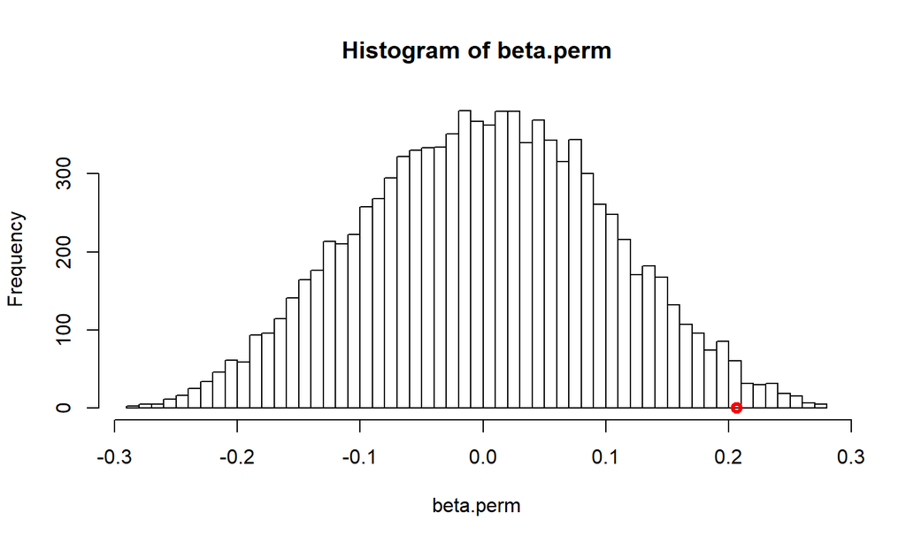

## How likely WAS \(\hat{\beta}_1 ^{obs}\)?

(before the experiment!)

Remarks:

## Calculation of the p-value

Over B=10^{4} permutations we got 9841 times a \(\hat{\beta}_1 ^{* b} \leq \hat{\beta}_1 ^{obs}\).

The p-value (significance) is \(p=\frac{\# (\hat{\beta}_1 ^{* b} \geq \hat{\beta}_1 ^{obs})}{B + 1} =\) 0.0161

## Interpretation

Neyman-Pearson's approach has made common the use of a significance threshold for example \(\alpha=.05\) (or \(=. 01\)). When \(p \leq \alpha\) rejects the hypothesis that there is no relationship between X and Y (\(H_0\)). If so, we are inclined to think that \(H_1\) is true (there is a positive relationship).

- Type I error: False Positive  
  the true hypo is \(H_0\) (null correlation), BUT we accept \(H_1\) (correlation is positive)
- Type II error: False Negative  
  the true hypo is \(H_1\) (positive correlation), BUT we do not reject \(H_0\) (null correlation)

**Type I error control**

We want to guarantee not to get false relationships (a few false positives), better to be conservative. To make this, we want to bound the probability to make a false discovery:

\(P (p-value \leq \alpha | H_0) \leq \alpha\)

We built a machinery that in the long run (many replicates of the experiment) finds false correlations with probability \(\alpha\) (e.g. \(0.05=5\%\)).

## We make it in `flip`

```r
library(flip)

(res=flip(Reaction.Time~Age,data=reaction,tail=1))
```

```
##
##               Test  Stat tail p-value
## Reaction.Time    t 2.633    >  0.0210
```

```r
## compare also with
# flip(Reaction.Time~Age,data=reaction,tail=1,statTest = "cor")
# flip(Reaction.Time~Age,data=reaction,tail=1,statTest = "coeff")
```

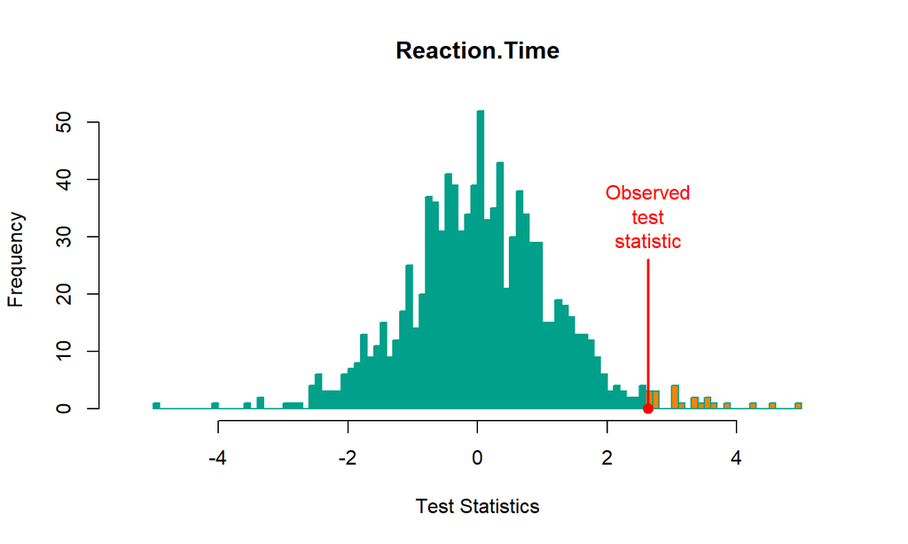

```r
plot(res)
```

## Composite alternatives (bilateral)

The hypothesis \(H_1: \ \beta_1 >0\) (the relation is positive) must be justified with a priori knowledge.

More frequently, the Alternative hypothesis is appropriate: \(H_1: \ \beta_1 \neq 0\) (there is a relationship, I do not assume the direction)

I consider anomalous coefficients estimated as very small but also very large ('far from 0'). The p-value is \(p=\frac{\#(|\hat{\beta}_1^{*b} | \geq|\hat{\beta}_1^{obs}|)}{B+1}=\) 0.0334

In `flip`:

```r
library(flip)
(res=flip(Reaction.Time~Age,data=reaction,tail=0,perms=5000))
```

```
##
##               Test  Stat tail p-value
## Reaction.Time    t 2.633   ><  0.0362
```

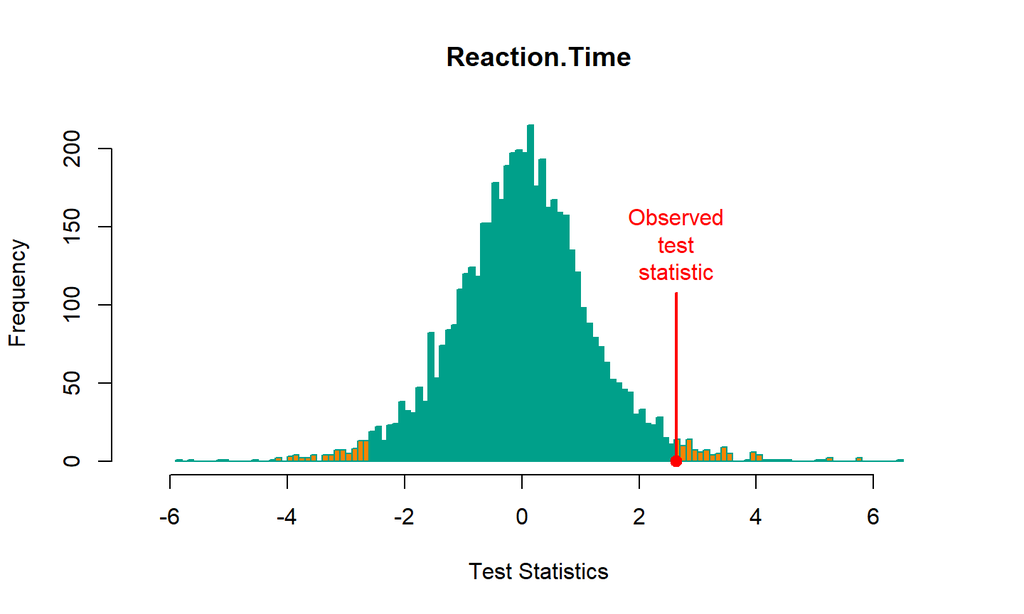

```r
plot(res)
```

## The permutation tests

- Do not be confused with bootstrap methods. The former are extractions without reintegration, the latter with. The former have almost optimal properties and have (almost always) an exact control of the first type errors.
- They constitute a general approach and are applicable in many contexts. Very few assumptions.
- Find some dedicated R library: [coin] (http://cran.r-project.org/web/packages/coin/index.html) and [flip] (http://cran.r-project.org/ web / packages / flip / index.html) (the development version is on [github] (https://github.com/livioivil/flip))
- They are of limited applicability when there are many variables involved.

## From permutation tests (non parametric) to parametric tests

We can see that the histogram of the statistical tests (calculated on the permuted data) is well described by a **Gaussian** (normal) curve.

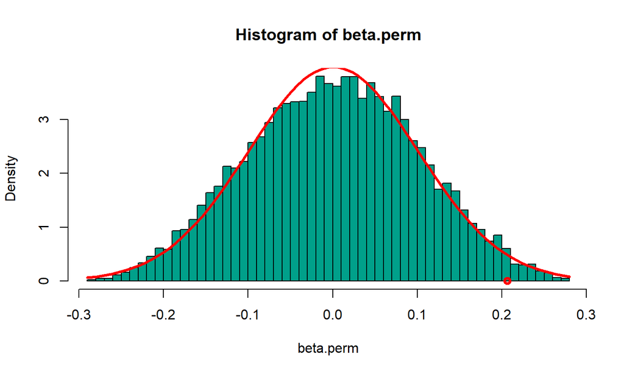

```r
hist(beta.perm,50,probability=TRUE,col=2)
curve(dnorm(x,mean(beta.perm),sd(beta.perm)),add=TRUE,col=1,lwd=3)
points(beta1,0,lwd=3,col=1)
```

## The (simple) linear model

We assume that the observed values are distributed around true values \(\beta_0 + \beta_1 X\) according to a Gaussian law:

\(Y=\textrm{linear part} + \textrm{normal error}\)

\(Y=\beta_0 + \beta_1 X + \varepsilon\)

**Assumptions of the linear model**

- the \(\boldsymbol{y_i=\beta_0 + \beta_1 x_i + \varepsilon_i}\) the relationship between X and Y is truly linear, less than the error term \(\varepsilon_i\)
- \(\boldsymbol{\varepsilon_i \sim N (0, \sigma ^ 2), \ \forall i=1, \ldots, n}\) errors have normal distribution with zero mean and common variance (homoschedasticity: same variance).

## Hypothesis testing

If these assumptions are true,

\(\hat{\beta_1} \sim N (\beta_1, \sigma ^ 2 / \sum (x_i- \bar{x}) ^ 2)\)

We calculate the test statistic:

\(t=\frac{\hat{\beta_1}}{std.dev\ \hat{\beta_1}}=\frac{\hat{\beta_1}}{\sqrt{\sum_{i=1} ^ n (y_i- \hat{y}_i) ^ 2 / \sum (x_i- \bar{x}) ^ 2 / (n-2)}}\)

If \(H_0: \beta_1=0\), \(t \sim t (n-2)\) is true

```r
model=lm (Reaction.Time ~ Age, data=reaction)
summary (model)
```

```
##
## Call:
## lm(formula = Reaction.Time ~ Age, data = reaction)
##
## Residuals:
##    Min     1Q Median     3Q    Max
## -6.535 -3.364 -0.272  2.676  7.839
##
## Coefficients:
##             Estimate Std. Error t value Pr(>|t|)
## (Intercept) 10.30135    4.04407   2.547   0.0343 *
## Age          0.20647    0.07841   2.633   0.0300 *
## ---
## Signif. codes:  0 '***' 0.001 '**' 0.01 '*' 0.05 '.' 0.1 ' ' 1
##
## Residual standard error: 4.678 on 8 degrees of freedom
## Multiple R-squared:  0.4643, Adjusted R-squared:  0.3973
## F-statistic: 6.934 on 1 and 8 DF,  p-value: 0.03003
```

Similar result, but much more assumptions!

## The Two-independent-sample problem

```r
data("seeds")
seeds=na.omit(seeds)

(res=flip(x~grp,data=seeds))
```

```
##
##   Test Stat tail p-value
## x    t 1.32   ><  0.1940
```

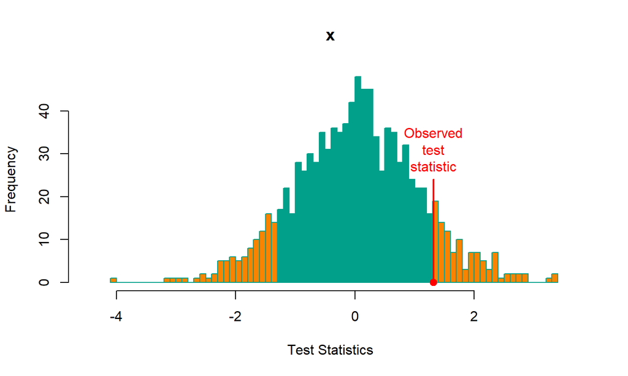

```r
plot(res)
```

## Chi square and other cathegorical methods

```r
data("seeds")
seeds$Germinated=!is.na(seeds$x)
seeds$Germinated=factor(seeds$Germinated)
seeds$grp=factor(seeds$grp)
(res=flip(Germinated~grp,data=seeds,statTest = "Chisq",perms=10000))
```

```
##
##                         Test  Stat tail p-value
## grp_|_Germinated Chi Squared 3.135    >  0.1573
```

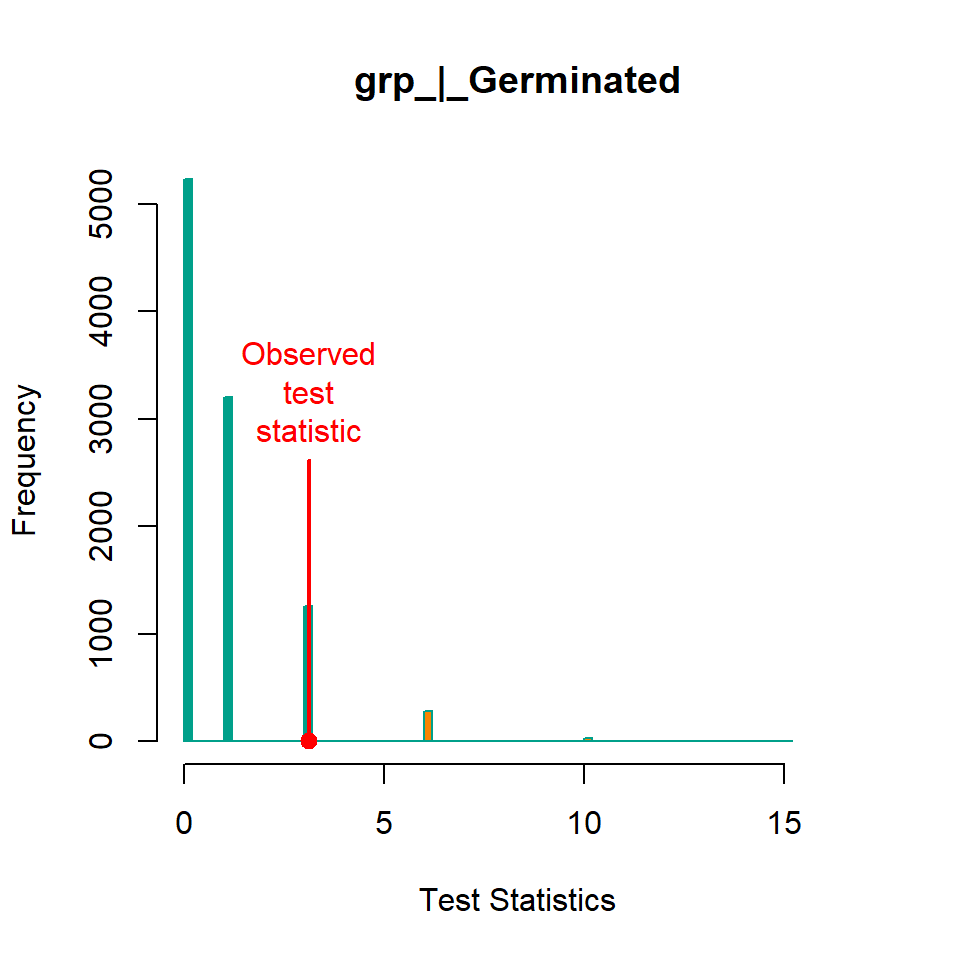

```r
plot(res)
```

… and the Fisher test:

```r
(flip(Germinated~grp,data=seeds,statTest = "Fisher",perms=10000))
```

```
##
##                   Test Stat tail p-value
## GerminatedFALSE Fisher    3   ><  0.1522
## GerminatedTRUE  Fisher   17   ><  0.1522
```

## Stratified permutations (nuisances)

```r
library(flip)
(res=flip(Reaction.Time~Age,data=reaction,perms=50000))
```

```
##
##               Test  Stat tail p-value
## Reaction.Time    t 2.633   ><  0.0343
```

```r
(res=flip(Reaction.Time~Age,Z=~Gender,data=reaction,perms=50000))
```

```
##
##               Test  Stat tail p-value
## Reaction.Time    t 2.776   ><  0.0186
```

```r
(res=flip(Reaction.Time~Age*Gender,Z=~Gender,data=reaction,perms=50000))
```

```
##
##                               Test  Stat tail p-value
## Reaction.Time_|_Age              t 2.570   ><  0.0186
## Reaction.Time_|_Age:Gender.M.    t 2.587   ><  0.0253
```

```r
npc(res)
```

```
##
##    comb.funct nVar  Stat p-value
## V1     Fisher    2 7.663  0.0156
```

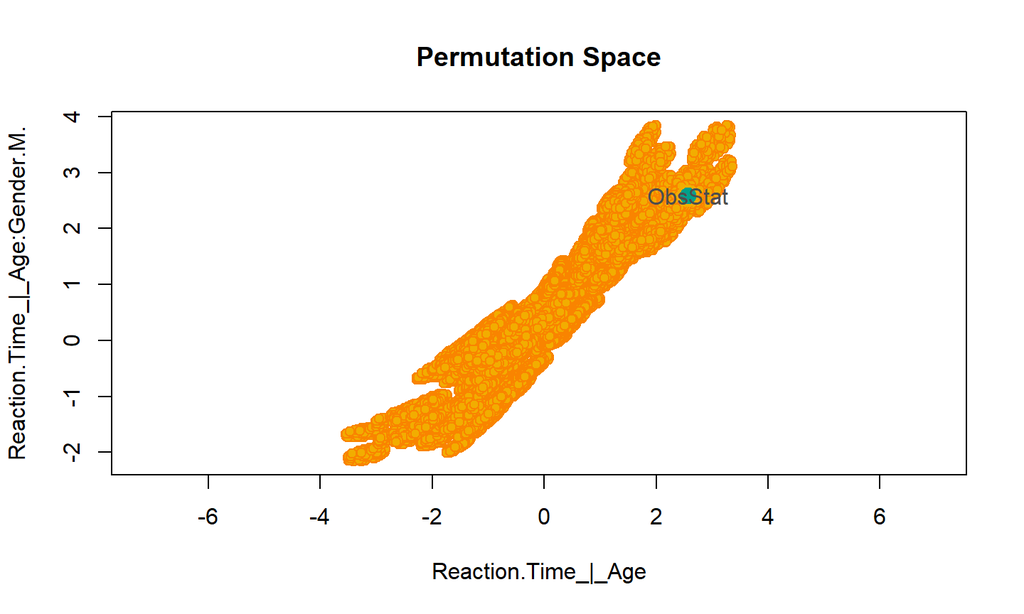

```r
plot(res)
```